# Data Processing for PREVENT-19 Stage 2 Delta Correlates

### Data descriptives

This dataset uses the updated clinical database, which is slightly different from the Stage 1 dataset.

The dataset contains vaccine arm only and seroneg only, but has both US and MEX.

There are 65 ptids in the stage 2 mapped data and not in the stage 1 mapped data

Variants

```r
with(subset(dat_proc, ph1.D35==1 & Country==0), mytable(VARTYPE_first, VARTYPE_first1))
```

```
##                      VARTYPE_first1
## VARTYPE_first         Alpha Delta Gamma  Iota Lambda    Mu Omicron   Unk  <NA>
##                           0     0     0     0      0     0       0   473 13674
##   Alpha                   1     0     0     0      0     0       0     0     0
##   Alpha, Alpha            1     0     0     0      0     0       0     0     0
##   Delta                   0   355     0     0      0     0       0     0     0
##   Delta, Delta            0    30     0     0      0     0       0     0     0
##   Delta, Delta, Delta     0     1     0     0      0     0       0     0     0
##   Delta, Omicron          0     1     0     0      0     0       0     0     0
##   Gamma                   0     0     2     0      0     0       0     0     0
##   Iota                    0     0     0     1      0     0       0     0     0
##   Lambda                  0     0     0     0      1     0       0     0     0
##   Mu                      0     0     0     0      0     4       0     0     0
##   Omicron                 0     0     0     0      0     0     531     0     0
##   Omicron, Omicron        0     0     0     0      0     0      54     0     0
```

```r
with(subset(dat_proc, ph1.D35==1 & Country==0), mytable(VARTYPE_first1, ph2.D35))
```

```
##               ph2.D35
## VARTYPE_first1 FALSE  TRUE
##        Alpha       2     0
##        Delta      65   322
##        Gamma       1     1
##        Iota        1     0
##        Lambda      1     0
##        Mu          3     1
##        Omicron   580     5
##        Unk       464     9
##        <NA>    13149   525
```

There are 8 severe cases with markers. There are four degrees of severity. **Less-than-mild cases are not counted cases or censoring events.**

```r
with(subset(dat_proc, ph1.D35==1 & Country==0), mytable(Severity_first, ph2.D35, EventIndFirstD1))
```

```
## , , EventIndFirstD1 = 0
##
##                 ph2.D35
## Severity_first   FALSE  TRUE
##                  13149   525
##   LESS THAN MILD     0     0
##   MILD               0     0
##   MODERATE           0     0
##   SEVERE             0     0
##
## , , EventIndFirstD1 = 1
##
##                 ph2.D35
## Severity_first   FALSE  TRUE
##                      0     0
##   LESS THAN MILD    54     1
##   MILD             967   293
##   MODERATE          90    36
##   SEVERE             6     8
```

Booster dose

- Getting COVID did not disqualify a person from getting the booster, but there are other eligibility criteria. About half of the ptids have missing BD1 date, and presumably not getting booster.
- Sampling was done regardless of having BD1 dates.
- There are no cases infected after BD.
- There were 10 non-cases censored after BD before we applied censoring by BD.

```r
mytable(dat_mapped$NumberdaysD1toBD1 - dat_mapped$DeltaEventTimeD1 < 0, dat_mapped$DeltaEventIndD1)
```

```
##
##            0    1
##   FALSE 8008  284
##   <NA>  8300  120
```

```r
with(subset(dat_mapped, ph1.D35==1 & Country==0 & DeltaEventIndD1==1), mytable(is.na(NumberdaysD1toBD1), !is.na(Day35bindSpike_Delta3)))
```

```
##
##         FALSE TRUE
##   FALSE    28  238
##   TRUE     19   91
```

Comparing number of ptids with markers in stage 1 and 2

```r
dat.tmp2=subset(dat_proc, ph1.D35==1 & Country==0 & Trt==1 & SubcohortInd==1)
sum(!is.na(dat.tmp2$Day35pseudoneutid50_D614G))
```

```
## [1] 629
```

```r
sum(!is.na(dat.tmp2$Day35pseudoneutid50_Delta))
```

```
## [1] 545
```

```r
sum(!is.na(dat.tmp2$Day35bindSpike_D614))
```

```
## [1] 540
```

```r
sum(!is.na(dat.tmp2$Day35bindSpike_Delta1))
```

```
## [1] 540
```

```r
sum(dat.tmp2$ph2.D35_108)
```

```
## [1] 442
```

```r
dat.tmp3=subset(dat_proc_stage1, ph1.D35==1 & Country==0 & Trt==1 & SubcohortInd==1)
sum(!is.na(dat.tmp3$Day35pseudoneutid50))
```

```
## [1] 885
```

```r
sum(!is.na(dat.tmp3$Day35bindSpike))
```

```
## [1] 882
```

```r
sum(dat.tmp3$ph2.D35)
```

```
## [1] 876
```

Some ptids have more than one COVID episodes

tfinal.tpeak is 305 for both Delta and severe COVID because the last case is a severe Delta COVID case.

```r
with(subset(dat_proc, Trt==1 & ph2.D35_108), sort(EventTimeD35_to21Dec10[DeltaEventIndD35_108to21Dec10==1], decreasing = T)[1:10])
```

```
##  [1] 305 301 297 289 289 286 286 286 285 285
```

```r
with(subset(dat_proc, Trt==1 & ph2.D35_108), sort(SevereEventTimeD35_to21Dec10[SevereEventIndD35_108to21Dec10==1], decreasing = T)[1:10])
```

```
##  [1] 305 297 279 228 205 190 190 175 130  NA
```

```r
subset(dat_proc, Trt==1 & ph2.D35_108 & EventTimeD35_to21Dec10==305)
```

```
##                          Ptid Trt EthnicityHispanic EthnicityNotreported
## 3968  2019nCoV-301-US097-0011   1                 0                    0
## 9449  2019nCoV-301-US179-0038   1                 0                    0
## 9461  2019nCoV-301-US179-0057   1                 0                    0
## 15272 2019nCoV-301-US232-0026   1                 1                    0
## 15500 2019nCoV-301-US235-0019   1                 0                    0
##       EthnicityUnknown Black Asian NatAmer PacIsl Multiracial Notreported
## 3968                 0     0     0       0      0           0           0
## 9449                 0     0     0       0      0           0           0
## 9461                 0     1     0       0      0           0           0
## 15272                0     0     0       0      0           0           0
## 15500                0     0     0       0      0           0           0
##       Unknown URMforsubcohortsampling HighRiskInd Sex Age  BMI Height    Weight
## 3968        0                       0           1   0  72 30.8 185.42 105.85034
## 9449        0                       0           1   0  61 36.9 175.26 113.28798
```

[output cut: 219 more lines]

vaccine group risk

```r
with(subset(dat_proc, Trt==1 & ph1.D35_108), mean(DeltaEventIndD35_108to21Dec10))
```

```
## [1] 0.02689634
```

### Adjusting endpoint follow-up period

Distribution of variant first (variant of the first COVID event). Not all Delta have markers b/c sampling requires DD1 samples.

```r
with(subset(dat_mapped, ph1.D35==1 & Country==0 ), mytable(VARTYPE_first1, !is.na(Day35bindSpike_Delta3)))
```

```
##
## VARTYPE_first1 FALSE  TRUE
##        Alpha       2     0
##        Delta      57   330
##        Gamma       1     1
##        Iota        1     0
##        Lambda      1     0
##        Mu          3     1
##        Omicron   580     5
##        Unk       464     9
##        <NA>    13142   532
```

All second episodes are after censoring. But if we push the censoring date out, the distribution of variants type between the first and second COVID events shows that Delta is always the first (data not shown).

Distribution of severity and variants. Note that less than mild are not counted as cases.

```r
with(subset(dat_mapped, ph1.D35==1), mytable(Severity_first, VARTYPE_first1, DeltaEventIndD35))
```

```
## , , DeltaEventIndD35 = 0
##
##                 VARTYPE_first1
## Severity_first   Alpha Delta Gamma  Iota Lambda    Mu Omicron   Unk  <NA>
##                      0     0     0     0      0     0       0     0 14408
##   LESS THAN MILD     0    13     0     0      0     0      14    31     0
##   MILD               4     0     4     1      1     4     599   421     0
##   MODERATE           0     0     1     0      0     1      61    41     0
##   SEVERE             0     0     0     0      0     0       3     6     0
##
## , , DeltaEventIndD35 = 1
##
##                 VARTYPE_first1
## Severity_first   Alpha Delta Gamma  Iota Lambda    Mu Omicron   Unk  <NA>
##                      0     0     0     0      0     0       0     0     0
##   LESS THAN MILD     0     0     0     0      0     0       0     0     0
##   MILD               0   357     0     0      0     0       0     0     0
##   MODERATE           0    39     0     0      0     0       0     0     0
##   SEVERE             0     8     0     0      0     0       0     0     0
```

Comparing timing of events of different variants, first using time since D35, second using calendar time. Ptids with markers are colored green. Based on the first plot, one proposal is to define the followup period to start at **108** days post the D35 visit, which includes all but two of the Delta cases that preceded the main wave. The Delta case on 108 days post D35 occurs on 2021-07-05. Based on the second plot, we replace censoring at the data cut date of 2022-03-26 by censoring at **2021-12-10** to avoid the Omicron wave at the end of 2021 and the beginning of 2022.

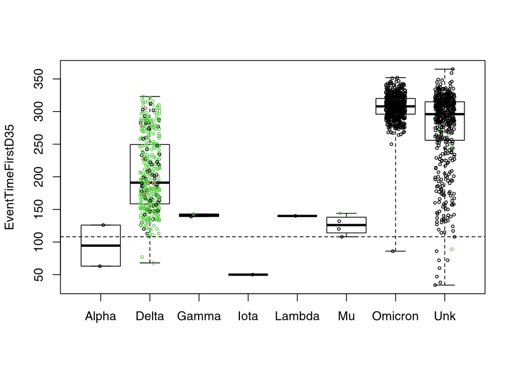

```r
# some severe are not EventIndFirstD1
col=with(dat, ifelse(Severity_first=="SEVERE" & ph2.D35 & EventIndFirstD1==1, 2, ifelse(ph2.D35,3,1)))

myboxplot(EventTimeFirstD35~VARTYPE_first1, dat, ylab="EventTimeFirstD35", col=col)
abline(h=108, lty=2)
```

```r
sort(subset(dat, VARTYPE_first1=="Delta", EventTimeFirstD35, drop=T))[1:5]
```

```
## [1]  68  77 108 111 112
```

```r
subset(dat, VARTYPE_first1=="Delta" & EventTimeFirstD35<=108, EventCalTimeFirstD35)
```

```
##       EventCalTimeFirstD35
## 6865            2021-05-02
## 9071            2021-05-14
## 13039           2021-07-05
```

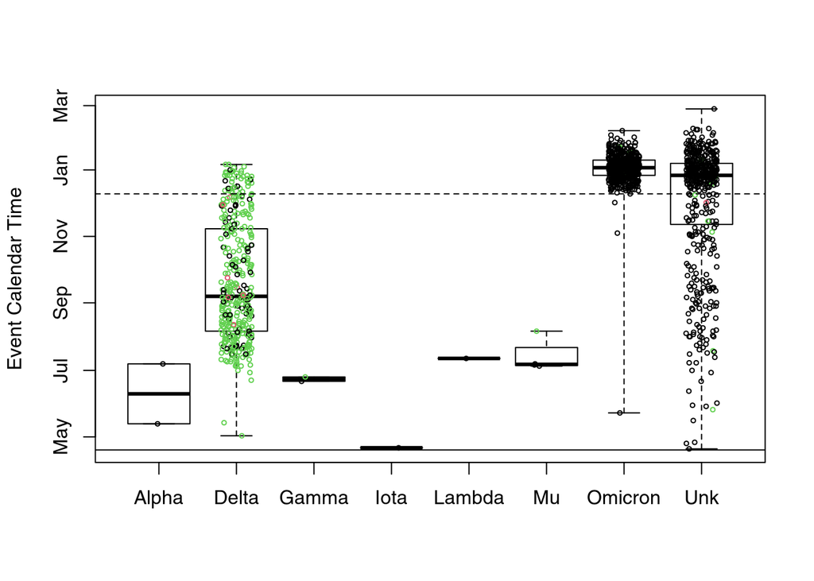

```r
myboxplot(EventCalTimeFirstD35~VARTYPE_first1, dat, ylab="Event Calendar Time", col=col)
abline(h=as.Date("2022-03-26")) # data cut
abline(h=as.Date("2021-04-19")) # data cut
abline(h=as.Date("2021-12-10"), lty=2)
```

```r
#Time of the first Delta case in EventIndD35_108to21Dec10
sort(subset(dat, DeltaEventIndD35_108to21Dec10==1, EventCalTimeFirstD35, drop=T))[1:10]
```

```
##  [1] "2021-06-22" "2021-06-29" "2021-07-01" "2021-07-05" "2021-07-05"
##  [6] "2021-07-06" "2021-07-06" "2021-07-07" "2021-07-09" "2021-07-09"
```

### Immunogenecity and imputation

Correlation is high among bAb markers (1 between the three Delta bAb markers) and high between the two nAb markers.

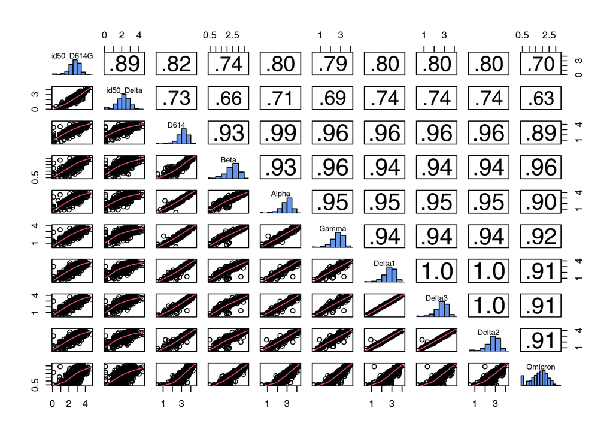

```r
dat.tmp=dat_mapped[,"Day35"%.%assays]
names(dat.tmp)=sub("Day35pseudoneut","",names(dat.tmp))
names(dat.tmp)=sub("Day35bindSpike_","",names(dat.tmp))
mypairs(dat.tmp)
```

Missingness across markers at D35

```r
dat.tmp=subset(dat_mapped)
for (i in 1:length(assays)) {
  dat.tmp[['tmp'%.%i]]=ifelse(is.na(dat.tmp[['Day35'%.%assays[i]]]), 0, 1)
}
dat.tmp$tmp=with(dat.tmp,paste0(tmp1,tmp2,tmp3,tmp4,tmp5,tmp6,tmp7,tmp8,tmp9,tmp10))
print(table(dat.tmp$tmp, dat.tmp$DeltaEventIndD35))
```

```
##
##                  0     1
##   0000000000 15215    47
##   0011111111     8     8
##   0111111111     6     2
##   1000000000   117     1
##   1011111111    15     2
##   1100000000    12     2
##   1111111111   596   342
```

Because the correlation between ancestral and Delta ID50s is 0.9, we will impute them if only one is missing. The bAb is all or none. We then restrict the ph2 samples to be the ptids with both bAb and nAb. Doing this allows us to compare nAb and bAb and avoid any batch effect in nAb.

```r
dat.tmp=subset(dat_mapped)
dat.tmp$tmp1 = !is.na(dat.tmp$Day35pseudoneutid50_D614G) | !is.na(dat.tmp$Day35pseudoneutid50_Delta)
dat.tmp$tmp2 = !is.na(dat.tmp$Day35bindSpike_Alpha)
dat.tmp$tmp=with(dat.tmp,paste0(as.integer(tmp1),as.integer(tmp2)))
print(table(dat.tmp$tmp, dat.tmp$DeltaEventIndD35))
```

```
##
##          0     1
##   00 15215    47
##   01     8     8
##   10   129     3
##   11   617   346
```

```r
subset(dat.tmp, tmp=="10" & Country==0, c(Subjectid))[1:10,]
```

```
##  [1] "2019nCoV-301-US003-0026" "2019nCoV-301-US012-0245"
##  [3] "2019nCoV-301-US013-0005" "2019nCoV-301-US013-0067"
##  [5] "2019nCoV-301-US013-0101" "2019nCoV-301-US013-0169"
##  [7] "2019nCoV-301-US019-0056" "2019nCoV-301-US027-0238"
##  [9] "2019nCoV-301-US027-0324" "2019nCoV-301-US039-0347"
```

Correlation between ancestral and Delta ID50s is high at each time point, and highest at BD1 (0.97) and DD1 (0.98).

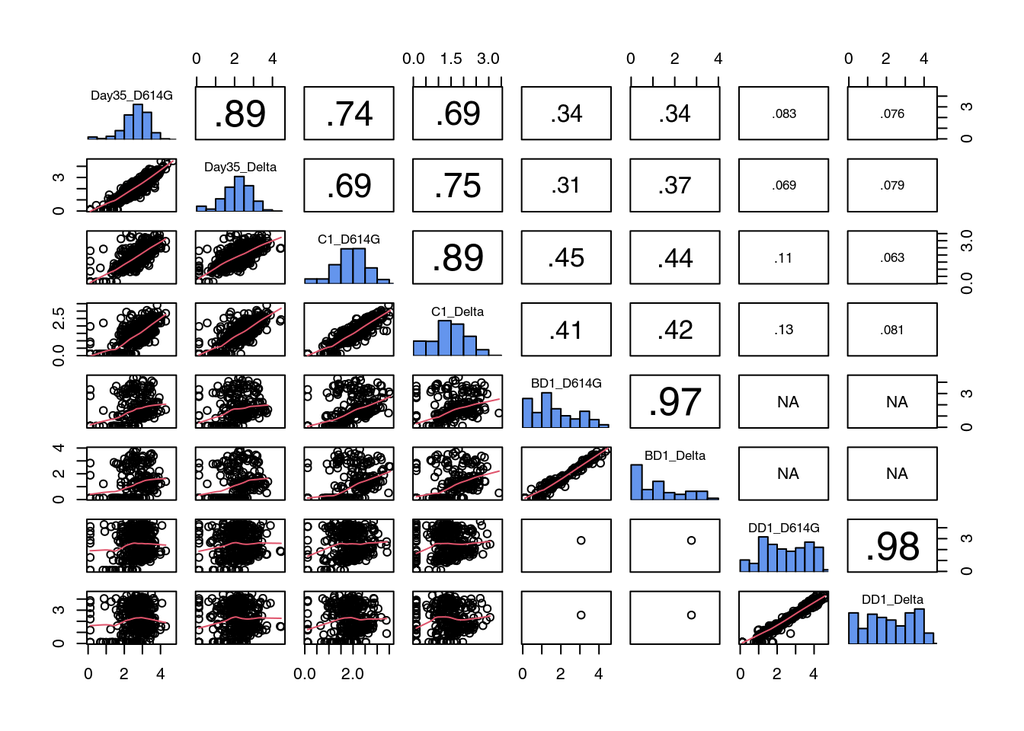

```r
dat.tmp=dat_mapped[,c(rbind(times%.%"pseudoneutid50_D614G",times%.%"pseudoneutid50_Delta"))]
names(dat.tmp)=sub("pseudoneutid50","",names(dat.tmp))
mypairs(dat.tmp)
```

A closer look at the correlation between ancestral ID50 and Delta ID50

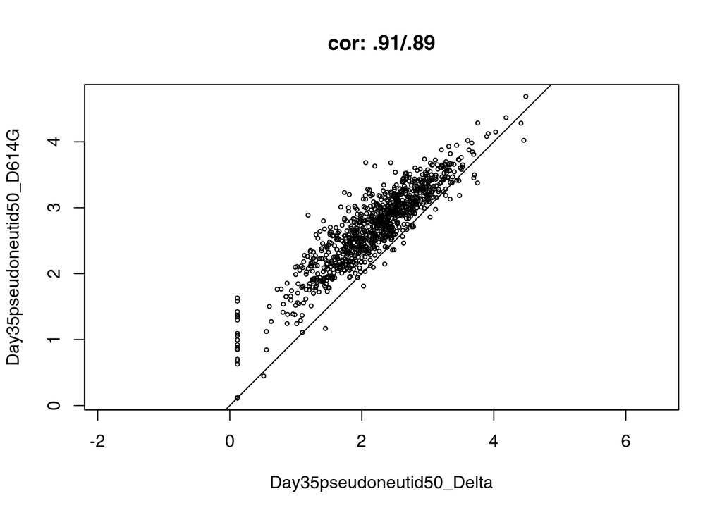

```r
corplot(Day35pseudoneutid50_D614G~Day35pseudoneutid50_Delta, dat_mapped, asp=1)
```

The following plot shows that Delta ID50 readouts are lower than ancestral ID50 and that marker level drops from D35 to C1 to BD1 as time goes by. At DD1, the markers rises, which suggests that they were influenced by the COVDID events

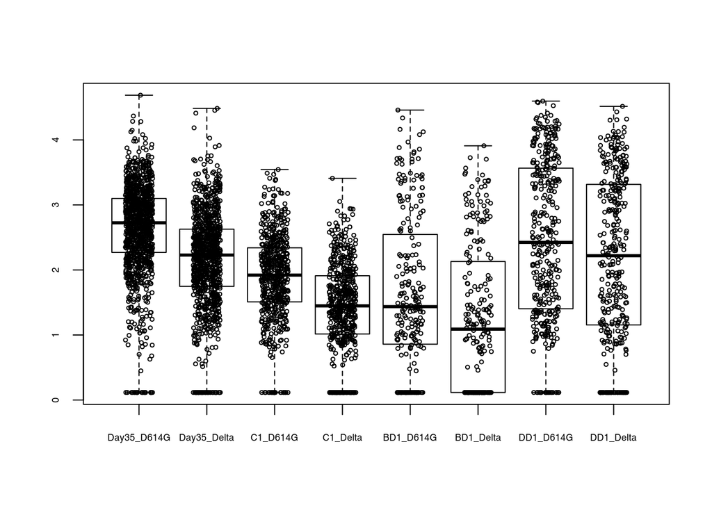

```r
dat.tmp=dat_mapped[,c(rbind(times%.%"pseudoneutid50_D614G",times%.%"pseudoneutid50_Delta"))]
names(dat.tmp)=sub("pseudoneutid50","",names(dat.tmp))
myboxplot(dat.tmp, cex.axis=0.55)
```

Missingness across two time points, D35 and C1, for ancestral id50

```r
for (j in 1:2){
  # change the comments to focus on different subsets
  dat.tmp=subset(dat_mapped)
  # dat.tmp=subset(dat_mapped, D35ancestralnAbBatch==23) # remove batch 1
  # dat.tmp=subset(dat_mapped, VARTYPE=="Delta") # delta cases

  v=ifelse(j==1,"D614G","Delta")
  print(v)

  for (i in 1:2) {
    dat.tmp[['tmp'%.%i]]=ifelse(is.na(dat.tmp[[times[i]%.%'pseudoneutid50_'%.%v]]), 0, 1)
  }
  dat.tmp$tmp=with(dat.tmp,paste0(tmp1,tmp2))
  print(table(dat.tmp$tmp))
  cat("\n")
}
```

```
## [1] "D614G"
##
##    00    01    10    11
## 15592    10   527   583
##
## [1] "Delta"
##
##    00    01    10    11
## 15725    11   448   528
```

Comparing titer between observed Delta cases and presumably Delta cases (Unk)

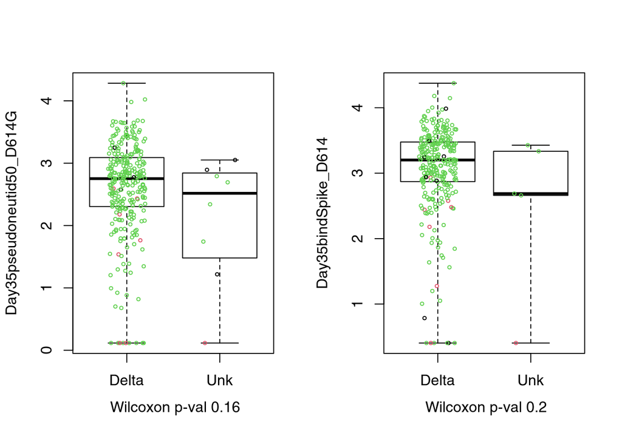

```r
dat.tmp=subset(dat, EventIndD35_7to21Dec10==1 & VARTYPE_first1 %in% c("Delta","Unk"))
col=with(dat.tmp, ifelse(Severity_first=="SEVERE" & ph2.D35 & EventIndFirstD1==1, 2, ifelse(ph2.D35,3,1)))
par(mfrow=c(1,2))
myboxplot(Day35pseudoneutid50_D614G~VARTYPE_first1, dat.tmp, test="w", col=col)
myboxplot(Day35bindSpike_D614~VARTYPE_first1, dat.tmp, test="w", col=col)
```

```r
summary(dat.tmp$Day35pseudoneutid50_D614G)
```

```
##    Min. 1st Qu.  Median    Mean 3rd Qu.    Max.    NA's
##  0.1159  2.2996  2.7443  2.5901  3.0592  4.2825     194
```

```r
summary(dat.tmp$Day35bindSpike_D614)
```

```
##    Min. 1st Qu.  Median    Mean 3rd Qu.    Max.    NA's
##  0.4043  2.8616  3.2006  3.0554  3.4690  4.3751     192
```

```r
subset(dat.tmp, VARTYPE_first1=="Unk" & !is.na(Day35pseudoneutid50_Delta), SubcohortInd)
```

```
##       SubcohortInd
## 3746             0
## 4027             0
## 7485             0
## 13438            0
## 16405            0
```

```r
subset(dat_mapped_stage1, Subjectid=='2019nCoV-301-US071-0032')
```

```
##                    Subjectid Trt EthnicityHispanic EthnicityNotreported
## 5163 2019nCoV-301-US071-0032   1                 0                    0
##      EthnicityUnknown Black Asian NatAmer PacIsl Multiracial Notreported
## 5163                0     0     0       0      0           0           0
##      Unknown URMforsubcohortsampling HighRiskInd Sex Age   BMI Height Weight
## 5163       0                       0           1   0  46 33.28  187.9  117.5
##      Country Region HIVinfection CalendarDateEnrollment NumberdaysD1toD21
## 5163       0      4            0                     10                22
##      NumberdaysD1toD35 Bserostatus Perprotocol BbindSpike Day35bindSpike
## 5163                36           0           1 -0.1695396       3.298532
##      BbindNVXIgG Day35bindNVXIgG BbindNVXIgGIU Day35bindNVXIgGIU BACE2
## 5163          NA              NA            NA                NA    NA
##      Day35ACE2 Bpseudoneutid50 Day35pseudoneutid50 SubcohortInd
## 5163        NA       0.1159432            3.051022            1
##      EarlyinfectionD21 EarlyinfectionD21start1 EarlyinfectionD35 AnyinfectionD1
## 5163                 0                       0                 0              0
##      BbindSpikeCPV Day35bindSpikeCPV Bpseudoneutid50CPV Day35pseudoneutid50CPV
## 5163            NA                NA                 NA                     NA
##      CPVsampInd EventTimePrimaryD1 EventIndPrimaryD1 EventTimePrimaryD21
## 5163         NA                106                 0                  84
##      EventIndPrimaryD21 EventTimePrimaryD35 EventIndPrimaryD35
## 5163                  0                  70                  0
```

#### Batch effect

679 D35 samples (including cases and non-cases) have ID50s measured twice by Monogram, once in Dec 21 in the Stage 1 work and once in July 23 in the Stage 2 work. The Pearson correlation is 0.88 between the two. Two-sample test by wilcoxon paired test p value is 6.046e-16. Applications that are sensitives to a shift of ~20% fold change in titers could be impacted.

```r
dat.2=read.csv('/trials/covpn/p3004/download_data/2019nCoV2-301_ nAB_D614G_27Oct2023 - 2.csv')

dat.2$batch=substr(dat.2$Monogram.Accession, 1, 2)
mytable(dat.2$batch)
```

```
##
##    21    22    23
##  1080 10026  3912
```

```r
mytable(dat.2$PVC, dat.2$Test.Method)
```

```
##
##                 SARS-COV-2 B16172 NEUT SARS-COV-2 D614G NEUT
##   Acute Illness                    146                   146
##   ACUTE ILLNESS                    238                   238
##   Booster D0                       122                   122
##   BOOSTER D0                       149                   149
##   Crossover V1                     294                   294
##   CROSSOVER V1                     335                   335
##   d0                                 0                     1
##   D0                                 0                  5663
##   D35                              668                  6118
```

```r
# find duplicated measurement of the same samples
dat.2.anc=subset(dat.2, Test.Method=='SARS-COV-2 D614G NEUT' & PVC=='D35')
dat.2.anc=dat.2.anc[order(dat.2.anc$Patient.Number),]

tmp = mytable(dat.2.anc$Patient.Number)
mytable(tmp)
```

```
## tmp
##    1    2    3
## 4775  670    1
```

```r
tmp[tmp==3] # US097-0021
```

```
## US097-0021
##          3
```

```r
subset(dat.2.anc, Patient.Number=='US097-0021')
```

```
##       Protocol.Code Monogram.Accession Accession.Container Patient.Number
## 1261   2019nCoV-301          22-100452         NCB98223-01     US097-0021
## 2329   2019nCoV-301          22-103468         NCF92392-01     US097-0021
## 13397  2019nCoV-301          23-175428         NCF92392-01     US097-0021
##       Collection.Date Collection.Time Visit.Description PVC
## 1261      15-Dec-2021        12:01 AM            DAY 35 D35
## 2329      29-Dec-2021        12:01 AM            DAY 35 D35
## 13397     08-Aug-2023        12:01 AM            DAY 35 D35
##                 Test.Method Titer.Result Unit.of.Results
## 1261  SARS-COV-2 D614G NEUT         < 40      1/Dilution
## 2329  SARS-COV-2 D614G NEUT          192      1/Dilution
## 13397 SARS-COV-2 D614G NEUT        ZNG40      1/Dilution
##       Reason.Not.Done.or.Comment.for.Result Specimen.Type batch
## 1261                                                SERUM    22
## 2329                                                SERUM    22
## 13397                                               SERUM    23
```

```r
dat.2.anc=subset(dat.2.anc, Patient.Number %in% names(tmp[tmp==2]))
dat.2.anc$batch = ifelse(startsWith(dat.2.anc$Monogram.Accession,'23'),2,1)

subset(dat.2.anc, Patient.Number=='US152-0064')
```

```
##       Protocol.Code Monogram.Accession Accession.Container Patient.Number
## 615    2019nCoV-301          21-175452         NCF48141-02     US152-0064
## 12684  2019nCoV-301          23-168960         NCF48141-02     US152-0064
##       Collection.Date Collection.Time Visit.Description PVC
## 615       01-Dec-2021        12:01 AM            DAY 35 D35
## 12684     25-Jul-2023        12:01 AM            DAY 35 D35
##                 Test.Method Titer.Result Unit.of.Results
## 615   SARS-COV-2 D614G NEUT         8282      1/Dilution
## 12684 SARS-COV-2 D614G NEUT        26859      1/Dilution
##       Reason.Not.Done.or.Comment.for.Result Specimen.Type batch
## 615                                                 SERUM     1
## 12684                                               SERUM     2
```

```r
dat.n=myreshapewide(Titer.Result~batch, dat.2.anc, 'Accession.Container')

clean=function(x) {
  x[x=='< 40']=20
  x[x=='ZNG40']=20
  as.integer((x))
}

dat.n$Titer.Result.1=clean(dat.n$Titer.Result.1)
dat.n$Titer.Result.2=clean(dat.n$Titer.Result.2)

dat.n$dif=log10(dat.n$Titer.Result.1)-log10(dat.n$Titer.Result.2)
summary(dat.n$dif)
```

```
##     Min.  1st Qu.   Median     Mean  3rd Qu.     Max.     NA's
## -1.82607 -0.21401 -0.07744 -0.07553  0.04591  2.74511       18
```

```r
summary(10**dat.n$dif)
```

```
##     Min.  1st Qu.   Median     Mean  3rd Qu.     Max.     NA's
##   0.0149   0.6109   0.8367   2.0406   1.1115 556.0500       18
```

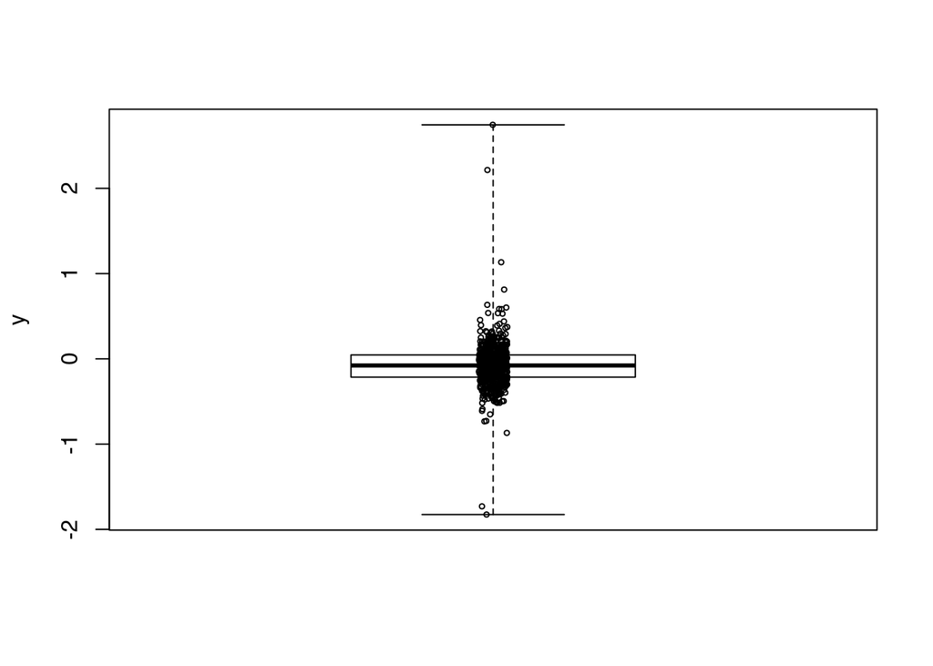

```r
myboxplot(list(dat.n$dif))
```

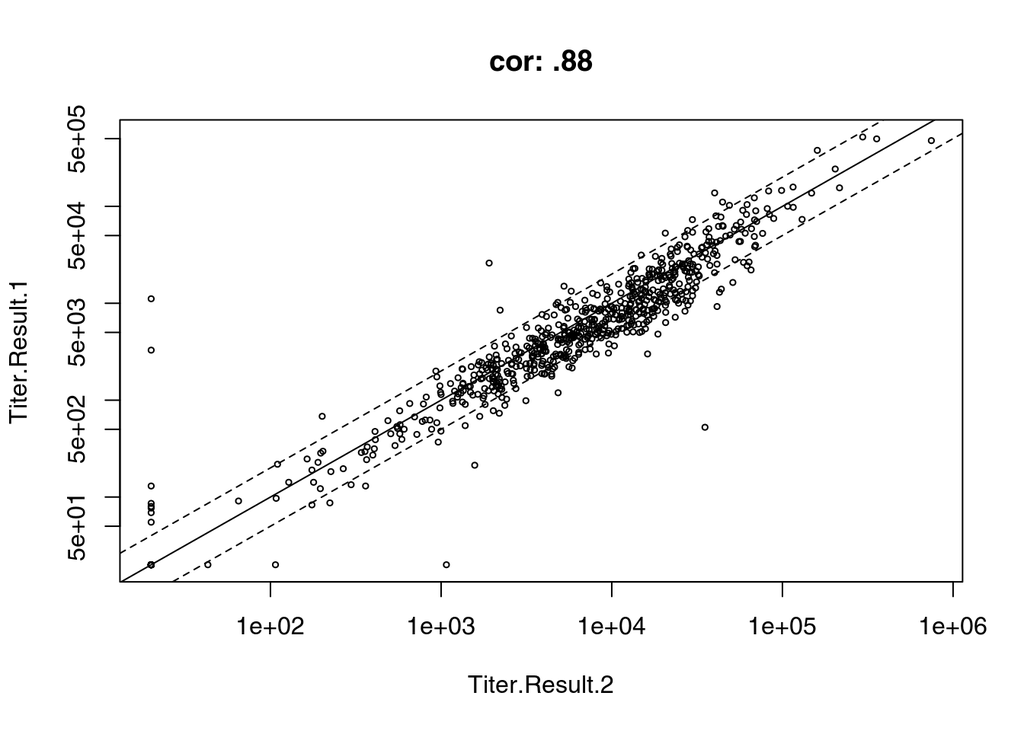

```r
corplot(Titer.Result.1~Titer.Result.2,dat.n, log='xy', method='p')
# abline(h=(8282), lty=2)
# abline(v=(26859), lty=2)
abline(a=-log10(2),b=1, lty=2) # 2 fold difference
abline(a=log10(2),b=1, lty=2)
```

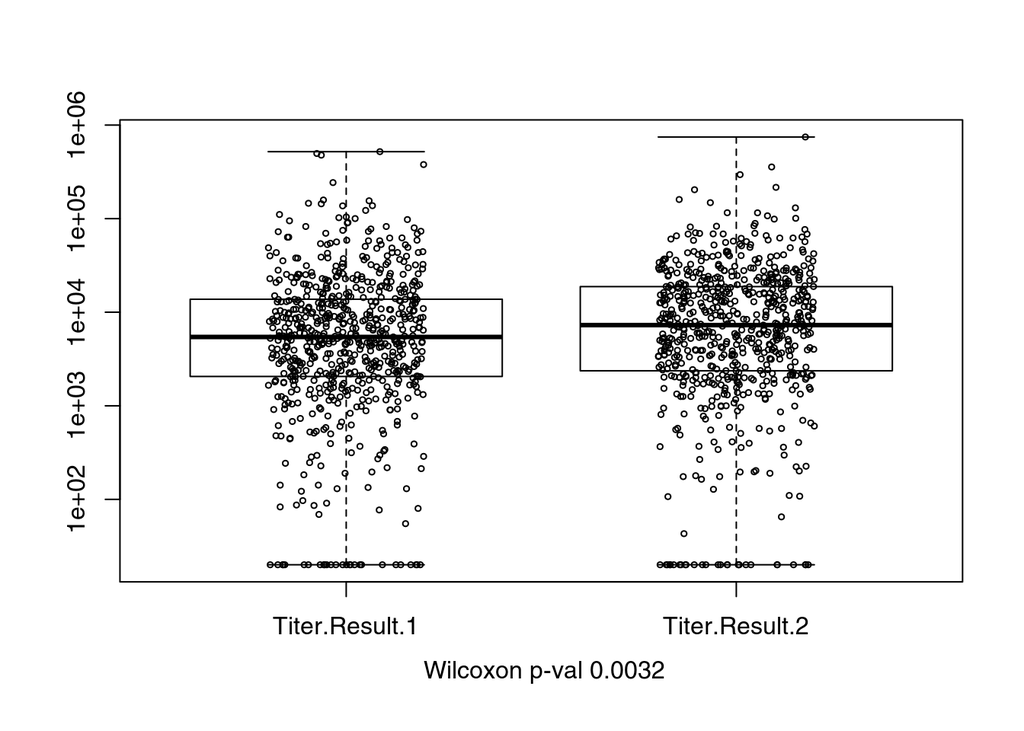

```r
myboxplot(dat.n[,c('Titer.Result.1','Titer.Result.2')], log='y', test='w')
```

```r
wilcox.test(dat.n$Titer.Result.1, dat.n$Titer.Result.2,paired=T)
```

```
##
##  Wilcoxon signed rank test with continuity correction
##
## data:  dat.n$Titer.Result.1 and dat.n$Titer.Result.2
## V = 65175, p-value = 6.046e-16
## alternative hypothesis: true location shift is not equal to 0
```

```r
nrow(dat.n)
```

```
## [1] 679
```

We use the later measurements when there are duplicates.

D35ancestralnAbBatch is the first two digits in the Monogram accession number and represents year. Most nAb were measured in 2023. Earlier samples may be from Stage 1 study.

```r
mytable(dat_mapped$D35ancestralnAbBatch)
```

```
##
##    21    22    23    24  <NA>
##    45    81   983     2 15601
```

### Two-phase sampling

Stage 2 sampling lists (Wayne):

- For the 402 cases, the time points of interest are D35 (after primary series in initial period), the acute illness visit associated with the Delta case, and crossover 1 (if applicable for subject). D35 may or may not be already tested earlier at the USG labs.
- For the 649 non-case, the D35 blood sample should already be at the USG lab from earlier.
  - The list of 279 non-cases is a subset of the list of 649. For the 279 subjects, the time points of interest are D35, crossover 1 and booster D0 - the database says these subjects should have all 3 visits/blood sample.

Number of cases in ph1 and ph2

```r
with(subset(dat_proc, ph1.D35==1 & Country==0 & Bserostatus==0 & Trt==1), mytable(ph2.D35, DeltaEventIndD35_108to21Dec10))
```

```
##        DeltaEventIndD35_108to21Dec10
## ph2.D35     0     1  <NA>
##   FALSE 11649    49  2568
##   TRUE    484   282    97
```

```r
with(subset(dat_proc, ph1.D35==1 & Country==0 & Bserostatus==0 & Trt==1), mytable(ph2.D35, SevereEventIndD35_108to21Dec10))
```

```
##        SevereEventIndD35_108to21Dec10
## ph2.D35     0     1  <NA>
##   FALSE 11696     3  2567
##   TRUE    758     8    97
```

```r
with(subset(dat_proc, ph1.D35==1 & Country==0 & Bserostatus==0 & Trt==1 & Severity_first=="SEVERE"), mytable(VARTYPE_first1, ph2.D35))
```

```
##               ph2.D35
## VARTYPE_first1 FALSE TRUE
##        Delta       1    7
##        Omicron     1    0
##        Unk         4    1
```

Distributions of samples by strata. Stratum 31 is Delta cases and 32 is severe cases. Note that non-Delta, non-severe cases are not sampled, so they are represented by the subcohort.

```r
with (subset(dat_proc, ph2.D35==1 & Trt==1 & Bserostatus==0 & Country==0), table(ph2.D35, Wstratum))
```

```
##        Wstratum
## ph2.D35  21  22  23  24  25  26  27  28  31  32
##    TRUE  93  75  77  70  58  69  42  57 314   8
```

### Covariates adjustment

Age affects immune response.

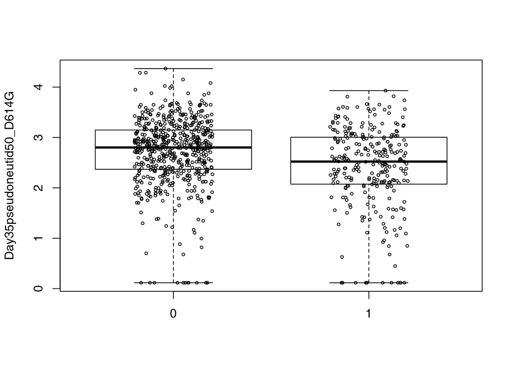

```r
myboxplot(Day35pseudoneutid50_D614G~Senior, subset(dat_proc, ph1.D35_108==1 & Country==0 & Trt==1))
```

Age>=65 is a stratification variable of the randomization and adjusted for in the primary efficacy analysis.

We will **adjust for Age in severe COVID correlates analyses**. Risk of severe COVID increases with age.

```r
coxph(Surv(SevereEventTimeD35_to21Dec10, SevereEventIndD35_108to21Dec10)~Age, subset(dat_proc, ph1.D35_108==1 & Country==0 & Trt==1))
```

```
## Call:
## coxph(formula = Surv(SevereEventTimeD35_to21Dec10, SevereEventIndD35_108to21Dec10) ~
##     Age, data = subset(dat_proc, ph1.D35_108 == 1 & Country ==
##     0 & Trt == 1))
##
##        coef exp(coef) se(coef)     z     p
## Age 0.04365   1.04462  0.02256 1.935 0.053
##
## Likelihood ratio test=4.1  on 1 df, p=0.04296
## n= 12435, number of events= 11
```

```r
coxph(Surv(SevereEventTimeD35_to21Dec10, SevereEventIndD35_108to21Dec10)~Senior, subset(dat_proc, ph1.D35_108==1 & Country==0 & Trt==1))
```

```
## Call:
## coxph(formula = Surv(SevereEventTimeD35_to21Dec10, SevereEventIndD35_108to21Dec10) ~
##     Senior, data = subset(dat_proc, ph1.D35_108 == 1 & Country ==
##     0 & Trt == 1))
##
##          coef exp(coef) se(coef)     z    p
## Senior 0.2618    1.2992   0.7897 0.331 0.74
##
## Likelihood ratio test=0.1  on 1 df, p=0.747
## n= 12435, number of events= 11
```

We will **adjust for age group in Delta COVID correlates analyses**. Risk of Delta COVID decreases with age group.

```r
coxph(Surv(EventTimeD35_to21Dec10, DeltaEventIndD35_108to21Dec10)~Age, subset(dat_proc, ph1.D35_108==1 & Country==0 & Trt==1))
```

```
## Call:
## coxph(formula = Surv(EventTimeD35_to21Dec10, DeltaEventIndD35_108to21Dec10) ~
##     Age, data = subset(dat_proc, ph1.D35_108 == 1 & Country ==
##     0 & Trt == 1))
##
##          coef exp(coef)  se(coef)      z      p
## Age -0.006748  0.993275  0.003709 -1.819 0.0689
##
## Likelihood ratio test=3.31  on 1 df, p=0.0688
## n= 12435, number of events= 331
```

```r
coxph(Surv(EventTimeD35_to21Dec10, DeltaEventIndD35_108to21Dec10)~Senior, subset(dat_proc, ph1.D35_108==1 & Country==0 & Trt==1))
```

```
## Call:
## coxph(formula = Surv(EventTimeD35_to21Dec10, DeltaEventIndD35_108to21Dec10) ~
##     Senior, data = subset(dat_proc, ph1.D35_108 == 1 & Country ==
##     0 & Trt == 1))
##
##           coef exp(coef) se(coef)      z      p
## Senior -0.3588    0.6985   0.1917 -1.872 0.0612
##
## Likelihood ratio test=3.87  on 1 df, p=0.04929
## n= 12435, number of events= 331
```